# weighted_2class_classification

```python
## This code cell will not be shown in the HTML version of this notebook
# imports from custom library
import sys
sys.path.append('../../')
from mlrefined_libraries import superlearn_library as superlearn
from mlrefined_libraries import math_optimization_library as optlib

# demos for this notebook
regress_plotter = superlearn.lin_regression_demos
optimizers = optlib.optimizers
static_plotter = optlib.static_plotter.Visualizer()
datapath = '../../mlrefined_datasets/superlearn_datasets/'

# import autograd functionality to bulid function's properly for optimizers
import autograd.numpy as np

# import timer
from datetime import datetime

# this is needed to compensate for %matplotlib notebook's tendancy to blow up images when plotted inline
%matplotlib notebook
from matplotlib import rcParams
rcParams['figure.autolayout'] = True
```

## 1.2 Weighted two-class classification

- Precisely the same sort of thing can arise with classification datasets i.e., weighted classification due to e.g., repeated points or confidence about the quality of individual points
- However perhaps an even more popular use of weighted classification: dealing with large class imbalances!
- Once again weightings determine *how important each datapoint is* in the training of the model

#### Example: Weighted classification: census data example

- When collecting metadata (e.g., census data) its easy to collect duplicates - multiple people having similar/the same stats based on your survey
- Duplication can also arise due to necessary and/or helpful pre-processing of such data - e.g., throwing away unnecessary points / features
- Here we take a popluar census dataset and show what happens along a single input / output when a common sort of pre-processing (quantizing) is performed - we end up with multiple entries of the same datapoint
- These datapoints should not be thrown away! They represent the true dataset.

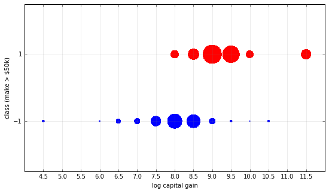

```python
demo3 = util.classification_library.weighted_classification_example.Visualizer()
csvname = 'weighted_superlearn_datasets/census_data.csv'
demo3.plot(csvname)
```

- The classification cost - in terms of its summands - will collapse into a weighted classification
- That is, if we use a softmax cost, the summands collapse and we have a weighted version

\begin{equation} g\left(\mathbf{w}\right) = \sum_{p=1}^P\beta_p\,\text{log}\left(1 + e^{-y_p\text{model}\left(x_p,\mathbf{w}\right)}\right) \end{equation}

- Here once again $\beta_p$ represent weights on each datapoint - here $\beta_p$ equals the number of times $\left(x_p,\,y_p\right)$ present in the dataset

```python
# a Python implementation of the weighted two-class softmax cost function
# setup to compute over mini-batches if desired
def softmax(w,x,y,beta,iter):
    # get batch of points
    x_p = x[:,iter]
    y_p = y[:,iter]
    beta_p = beta[:,iter]

    # compute cost over batch
    cost = np.sum(beta_p*np.log(1 + np.exp(-y_p*model(x_p,w))))
    return cost/float(np.size(y_p))
```

#### Example: Weighted classification: large class imbalances example

- Weighting is often used to deal with *class imbalances*
- On such datasets it is often easy to achieve a high accuracy by assigning all data to the larger class
  - however this often comes at the expense of misclassifying members from the smaller class which - depending on the application - is not desired
  - for example, if the classification determines whether or not someone has a particular deadly disease that requires further testing we would not want to miss them
- All classifiers are succeptible to poor classification results when dealing with datasets with large class imbalances
- But since all classifiers sum over datapoints individually we can re-weight each to compensate
- To alter the behavior of the learned classifier we note that more points from the larger class are being used than points from the smaller class
- So if we add a weight $0 < \beta_p < 1$ to each summand including a point from the larger class, and a weight $\beta_P > 1$ to summands including points from the smaller set, we incentivse the learning of a decision boundary that better favors the minority class
- Along these lines, it is common to assign such weigths *inversely proportional to the number of members of each class*
- So say $P_{\text{large}}$ and $P_{\text{small}}$ are the number of points in a two-class dataset from the larger / smaller classes respectively, and $P= P_{\text{large}} + P_{\text{small}}$ is total number of points then assign $\beta_{\text{large}}$ and $\beta_{\text{small}}$ to the summand containing points from the large / small class as (where $k$ is a constant)

\begin{array} \ \beta_{\text{large}} = \frac{k}{P_{\text{large}}} \\ \beta_{\text{small}} = \frac{k}{P_{\text{small}}} \\ \end{array}

- Below weight of minority class is increased as you move slider from left to right, with new classification shown as result (and point size of minority red class increased for visualization)
- As you increase the weighting on minority class members you incentivise learned classifier to classify these points correctly

```python
csvname = 'weighted_superlearn_datasets/3d_classification_data_v2.csv'
demo4 = util.classification_library.weighted_classification_animator.Visualizer()
demo4.animate_weightings(csvname,num_slides = 20)
```

[figure not shown]